# Reproducible Research: Peer Assessment 1

## Loading and preprocessing the data

```r
act<-read.csv("/Users/ankan/Documents/data/activity.csv", header=TRUE)
```

## What is mean total number of steps taken per day?

#### Histogram of the total number of steps taken each day.

```r
library(dplyr)
```

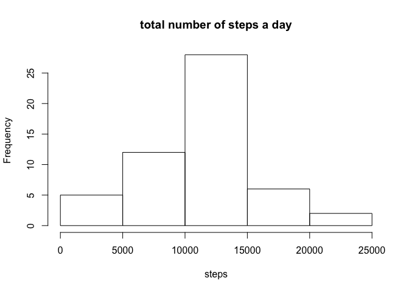

```r
act2 <- act %>%
        select(steps, date) %>%
        group_by(date) %>%
        summarize_each(list(sum))
hist(act2$steps, xlab="steps", main="total number of steps a day")
```

#### The mean and median total number of steps taken per day.

```r
mean(act2$steps, na.rm = TRUE)
```

```
## [1] 10766.19
```

```r
median(act2$steps, na.rm = TRUE)
```

```
## [1] 10765
```

## What is the average daily activity pattern?

#### Time series plot of the 5-minute interval (x-axis) and the average number of steps taken, averaged across all days (y-axis).

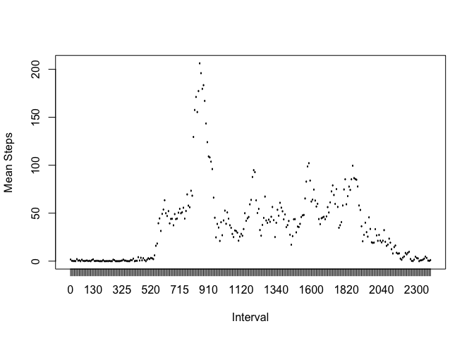

```r
actnaomit<-na.omit(act)
act3 <- actnaomit %>%
        select(steps, interval) %>%
        group_by(interval) %>%
        summarize_each(list(mean))
plot(factor(act3$interval),act3$steps, type="l", xlab="Interval", ylab="Mean Steps")
```

#### The 5-minute interval, on average across all the days in the dataset, that contains the maximum number of steps is 0835-0840.

```r
act4 <- act3 %>%
        filter(steps==max(act3$steps))
act4
```

```
## # A tibble: 1 x 2
##   interval steps
##      <int> <dbl>
## 1      835  206.
```

## Imputing missing values

#### The total number of missing values in the dataset (i.e. the total number of rows with NAs) is 2304.

```r
length(act$steps)-length(actnaomit$steps)
```

```
## [1] 2304
```

#### New dataset that is equal to the original dataset but with the missing data filled in as the mean value for all non missing observations.

```r
act<-mutate(act,nasteps=mean(steps,na.rm=TRUE))
actnaomit<-na.omit(act)
act5<-subset(act, is.na(steps))
act5$steps<-act5$nasteps
act6<-rbind(act5,actnaomit)
```

#### Histogram of the total number of steps taken each day with the new dataset.

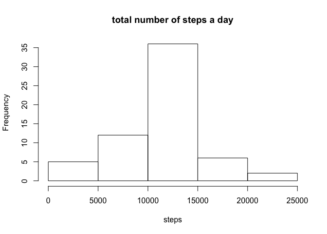

```r
act7 <- act6 %>%
        select(steps, date) %>%
        group_by(date) %>%
        summarize_each(list(sum))
hist(act7$steps, xlab="steps", main="total number of steps a day")
```

#### The mean and median total number of steps taken per day in the new dataset.

```r
mean(act7$steps)
```

```
## [1] 10766.19
```

```r
median(act7$steps)
```

```
## [1] 10766.19
```

## Are there differences in activity patterns between weekdays and weekends?

#### Create a new factor variable in the dataset with two levels – “weekday” and “weekend” indicating whether a given date is a weekday or weekend day.

```r
library(lubridate)
act6$weekday<-wday(act6$date)
act6$weekday<-replace(act6$weekday,act6$weekday==1|act6$weekday==7,'weekend')
act6$weekday<-replace(act6$weekday,act6$weekday!='weekend','weekday')
```

#### Panel plot containing a time series plot (i.e. type = “l”) of the 5-minute interval (x-axis) and the average number of steps taken, averaged across all weekday days or weekend days (y-axis).

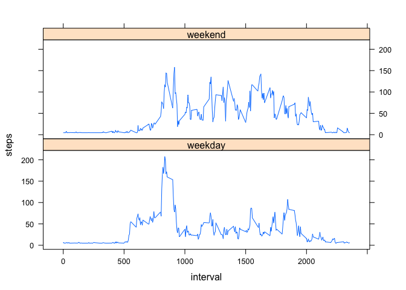

```r
act8 <- act6 %>%
        select(steps, interval, weekday) %>%
        group_by(interval,weekday) %>%
        summarize_each(list(mean))
library(lattice)
xyplot(steps ~ interval | weekday, data = act8, type="l", layout = c(1, 2))
```